# Pixar Movies Analysis

Dataset: Pixar Films

Source: https://mavenanalytics.io/challenges/maven-pixar-challenge/967013fc-1ff2-4453-a1ac-1ac1e0624c52

GitHub Source: https://github.com/erictleung/pixarfilms

The project is going to use the following tables:

- Films (Title, Release Date, Duration)
- Genres (Title, Category, Value)
- Box Office (Title, Budget, Box Office Worldwide)
- Review (Title, IMDB Score, IMDB Counts)

The goal of the project is to analyze the dataset dedicated to Pixar Movies. During this analysis we are going to try to predict the worldwide box office revenue (profit) of Pixar films based on their budget, release year, duration, genres.

The plan is following:

- to preprocess data;
- to show distributions of different feachers;
- to show correlation 'rating' and 'budget' and 'box office';
- to predict a box office depending on budget, genre, duration.

## PREPROCESSING

```python
# import necessary libraries
import pandas as pd
import matplotlib.pyplot as plt
import seaborn as sns
import os
import matplotlib.ticker as tick
from matplotlib.backends.backend_pdf import PdfPages
from sklearn.model_selection import train_test_split
from sklearn.linear_model import LinearRegression
from sklearn.ensemble import RandomForestRegressor
from sklearn.metrics import mean_absolute_error, mean_squared_error, r2_score
import numpy as np
```

### 1. PREPROCESS TABLE: PIXAR_FILMS

In this part of the project we are interested in filtering data. We do not need such columns as **'number'**, **'film_rating'** and **'plot'**. Thus, these columns will be dropped.

Also we should check the data on the missing values and duplicates.

In addition, we will describe the shape of the dataset.

```python
# Read the dataset
pixar_films = pd.read_csv("pixar_films.csv")

# Display the first few rows of the dataset
pixar_films.head()
```

|  | number | film | release_date | run_time | film_rating | plot |
| --- | --- | --- | --- | --- | --- | --- |
| 0 | 1 | Toy Story | 1995-11-22 | 81 | G | A cowboy doll is profoundly threatened and jea... |
| 1 | 2 | A Bug's Life | 1998-11-25 | 95 | G | A misfit ant, looking for "warriors" to save h... |
| 2 | 3 | Toy Story 2 | 1999-11-24 | 92 | G | When Woody is stolen by a toy collector, Buzz ... |
| 3 | 4 | Monsters, Inc. | 2001-11-02 | 92 | G | In order to power the city, monsters have to s... |
| 4 | 5 | Finding Nemo | 2003-05-30 | 100 | G | After his son is captured in the Great Barrier... |

```python
# Display the columns of the dataset
pixar_films.columns
```

```
Index(['number', 'film', 'release_date', 'run_time', 'film_rating', 'plot'], dtype='object')
```

```python
# Delete unnecessary columns
pixar_films = pixar_films.drop(columns=['number', 'film_rating', 'plot'])

# Display the first few rows of the dataset
pixar_films.head()
```

|  | film | release_date | run_time |
| --- | --- | --- | --- |
| 0 | Toy Story | 1995-11-22 | 81 |
| 1 | A Bug's Life | 1998-11-25 | 95 |
| 2 | Toy Story 2 | 1999-11-24 | 92 |
| 3 | Monsters, Inc. | 2001-11-02 | 92 |
| 4 | Finding Nemo | 2003-05-30 | 100 |

```python
# Check for missing values
print(pixar_films.isnull().sum())

# Check for duplicates
print(pixar_films.duplicated().sum())
```

```
film            0
release_date    0
run_time        0
dtype: int64
0
```

```python
# Convert date
pixar_films['release_date'] = pd.to_datetime(pixar_films['release_date'], errors='coerce')
```

```python
# Extract year
pixar_films['release_year'] = pixar_films['release_date'].dt.year
```

```python
# Check runtime
pixar_films['run_time'] = pd.to_numeric(pixar_films['run_time'], errors='coerce')
```

```python
# Display the column types
pixar_films.dtypes
```

```
film                    object
release_date    datetime64[ns]
run_time                 int64
release_year             int32
dtype: object
```

```python
# Display the shape of the dataset
pixar_films.shape
```

```
(28, 4)
```

The finale view of the first table named 'pixar_films' is following:

```python
# The preprocessed dataset
# Display the first few rows of the dataset
(pixar_films.head())
```

|  | film | release_date | run_time | release_year |
| --- | --- | --- | --- | --- |
| 0 | Toy Story | 1995-11-22 | 81 | 1995 |
| 1 | A Bug's Life | 1998-11-25 | 95 | 1998 |
| 2 | Toy Story 2 | 1999-11-24 | 92 | 1999 |
| 3 | Monsters, Inc. | 2001-11-02 | 92 | 2001 |
| 4 | Finding Nemo | 2003-05-30 | 100 | 2003 |

### 2. PREPROCESS TABLE: GENRES

Here we will check the data on missing values and duplicates. Just in case, we will check that all the films in this dataset match the movies in the 'pixar_films' dataset.

After that we will look at the shape of the dataset.

```python
# Read the dataset
genres = pd.read_csv("genres.csv")

# Display the first few rows of the dataset
(genres.head())
```

|  | film | category | value |
| --- | --- | --- | --- |
| 0 | Toy Story | Genre | Adventure |
| 1 | Toy Story | Genre | Animation |
| 2 | Toy Story | Genre | Comedy |
| 3 | Toy Story | Subgenre | Buddy Comedy |
| 4 | Toy Story | Subgenre | Computer Animation |

```python
# Check for missing values
print(genres.isna().sum())

# Check for duplicates
print(genres.duplicated().sum())
```

```
film        0
category    0
value       0
dtype: int64
0
```

```python
# Print the count of values in the 'category' column
print(genres['category'].value_counts())
```

```
category
Subgenre    120
Genre        84
Name: count, dtype: int64
```

```python
# Check if all films exist in main film table
missing_titles = set(genres['film']) - set(pixar_films['film'])
print("Titles not matched in pixar_films:", missing_titles)
```

```
Titles not matched in pixar_films: set()
```

The dataset is ready for usage. It looks like the following:

```python
# Display the first few rows of the dataset
(genres.head())
```

|  | film | category | value |
| --- | --- | --- | --- |
| 0 | Toy Story | Genre | Adventure |
| 1 | Toy Story | Genre | Animation |
| 2 | Toy Story | Genre | Comedy |
| 3 | Toy Story | Subgenre | Buddy Comedy |
| 4 | Toy Story | Subgenre | Computer Animation |

### 3. PREPROCESS TABLE: BOX_OFFICE

Now we have got the dataset with exstra info which is not needed. Thus we will delete the following columns: 'box_office_us_canada', 'box_office_other'. Likewise, we will check the data on missing values and duplicates. As in previous chapter, we will check that all the films in this dataset match the movies in the 'pixar_films' dataset. Moreover, we will check the numerical characterictics for an unexpected values.

After that we will look at the shape of the dataset.

```python
# Read the dataset and state the missing values
box_office = pd.read_csv("box_office.csv", na_values=['NA', 'NaN', 'N/A'])

# Display the first few rows of the dataset
(box_office.head())
```

|  | film | budget | box_office_us_canada | box_office_other | box_office_worldwide |
| --- | --- | --- | --- | --- | --- |
| 0 | Toy Story | 30000000.0 | 223225679 | 171210907 | 394436586 |
| 1 | A Bug's Life | 120000000.0 | 162798565 | 200460294 | 363258859 |
| 2 | Toy Story 2 | 90000000.0 | 245852179 | 265506097 | 511358276 |
| 3 | Monsters, Inc. | 115000000.0 | 255873250 | 272900000 | 528773250 |
| 4 | Finding Nemo | 94000000.0 | 339714978 | 531300000 | 871014978 |

```python
# Drop unnecessary columns
box_office = box_office.drop(columns=['box_office_us_canada', 'box_office_other'])
```

```python
# Fill missing values
missing_budget = box_office[box_office['budget'].isna()]
print("Films with missing budgets:\n", missing_budget)
```

```
Films with missing budgets:
     film  budget  box_office_worldwide
23  Luca     NaN              51112314
```

```python
# Replace missing budgets with mean
box_office['budget'] = box_office['budget'].fillna(box_office['budget'].mean())
```

```python
# Check for missing values
print(pixar_films.isnull().sum())

# Check for duplicates
print(pixar_films.duplicated().sum())
```

```
film            0
release_date    0
run_time        0
release_year    0
dtype: int64
0
```

```python
# Check for unexpected values
print("Zero/negative budgets:", box_office[box_office['budget'] <= 0])
print("Zero/negative box office:", box_office[box_office['box_office_worldwide'] <= 0])
```

```
Zero/negative budgets: Empty DataFrame
Columns: [film, budget, box_office_worldwide]
Index: []
Zero/negative box office: Empty DataFrame
Columns: [film, budget, box_office_worldwide]
Index: []
```

```python
# Check all films exist
missing_titles = set(box_office['film']) - set(pixar_films['film'])
print("Missing in pixar_films:", missing_titles)
```

```
Missing in pixar_films: set()
```

The dataset is fixed and ready for future analyses.

```python
# Display the first few rows of the dataset
(box_office.head())
```

|  | film | budget | box_office_worldwide |
| --- | --- | --- | --- |
| 0 | Toy Story | 30000000.0 | 394436586 |
| 1 | A Bug's Life | 120000000.0 | 363258859 |
| 2 | Toy Story 2 | 90000000.0 | 511358276 |
| 3 | Monsters, Inc. | 115000000.0 | 528773250 |
| 4 | Finding Nemo | 94000000.0 | 871014978 |

### 4. PREPROCESS TABLE: PUBLIC_RESPONSE

In this part we will do the same checks as in the previous one.

```python
# Read the dataset
reviews = pd.read_csv("public_response.csv")

# Display the first few rows of the dataset
(reviews.head())
```

|  | film | rotten_tomatoes_score | rotten_tomatoes_counts | metacritic_score | metacritic_counts | cinema_score | imdb_score | imdb_counts |
| --- | --- | --- | --- | --- | --- | --- | --- | --- |
| 0 | Toy Story | 100 | 96 | 95 | 26 | A | 8.3 | 1089101 |
| 1 | A Bug's Life | 92 | 91 | 78 | 23 | A | 7.2 | 319596 |
| 2 | Toy Story 2 | 100 | 172 | 88 | 34 | A+ | 7.9 | 630573 |
| 3 | Monsters, Inc. | 96 | 199 | 79 | 35 | A+ | 8.1 | 1000657 |
| 4 | Finding Nemo | 99 | 270 | 90 | 38 | A+ | 8.2 | 1132877 |

```python
# drop from the dataset 'reviews' columns 'rotten_tomatoes_score', 'rotten_tomatoes_counts', 'metacritic_score', 'metacritic_counts', 'cinema_score'
reviews = reviews.drop(columns=['rotten_tomatoes_score', 'rotten_tomatoes_counts', 'metacritic_score', 'metacritic_counts', 'cinema_score'])
```

```python
# check the dataframe contains null values
print(reviews.isnull().sum())

# check the dataframe contains duplicated values
print(reviews.duplicated().sum())
```

```
film           0
imdb_score     0
imdb_counts    0
dtype: int64
0
```

```python
# check the columns 'imdb_score', 'imdb_counts' contains unexpected values
print("Zero/negative imdb_score:", reviews[reviews['imdb_score'] <= 0])
print("Zero/negative imdb_counts:", reviews[reviews['imdb_counts'] <= 0])
```

```
Zero/negative imdb_score: Empty DataFrame
Columns: [film, imdb_score, imdb_counts]
Index: []
Zero/negative imdb_counts: Empty DataFrame
Columns: [film, imdb_score, imdb_counts]
Index: []
```

```python
# check if all the films exist in the main film table
missing_titles = set(reviews['film']) - set(pixar_films['film'])
print("Titles not matched in pixar_films:", missing_titles)
```

```
Titles not matched in pixar_films: set()
```

The dataset is tottaly ok and ready.

```python
# Print the first few rows of the dataset
(reviews.head())
```

|  | film | imdb_score | imdb_counts |
| --- | --- | --- | --- |
| 0 | Toy Story | 8.3 | 1089101 |
| 1 | A Bug's Life | 7.2 | 319596 |
| 2 | Toy Story 2 | 7.9 | 630573 |
| 3 | Monsters, Inc. | 8.1 | 1000657 |
| 4 | Finding Nemo | 8.2 | 1132877 |

## VISUALIZATION

```python
fig_dir='figures'
fig_file = 'my_figures.jpg'

if not os.path.exists(fig_dir):
    os.makedirs(fig_dir)
try:
    os.remove(fig_file)
except OSError:
    pass

pp = PdfPages(fig_file)
```

Let's display the distribution of the Pixar Films released by year.

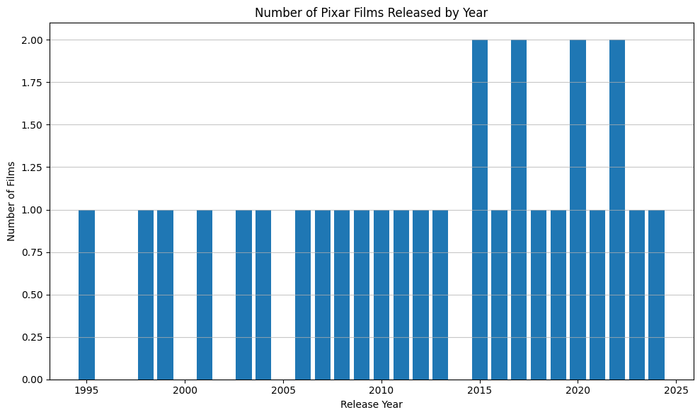

```python
# Count the number of films released per year
films_per_year = pixar_films['release_year'].value_counts().sort_index()

plt.figure(figsize=(10, 6))
plt.bar(films_per_year.index, films_per_year.values)
plt.title('Number of Pixar Films Released by Year')
plt.xlabel('Release Year')
plt.ylabel('Number of Films')
plt.grid(axis='y', linestyle='-', alpha=0.7)
plt.tight_layout()
plt.savefig(os.path.join(fig_dir, 'Distribution of the film number by year.jpg'), format='jpg', dpi=300)
plt.show()
```

As we see on the grafic, on average, the company produces one movie per year. There are some gaps with no films produced and some picks with at most 2 films released.

Let's display the average run time of Pixar Films by Year.

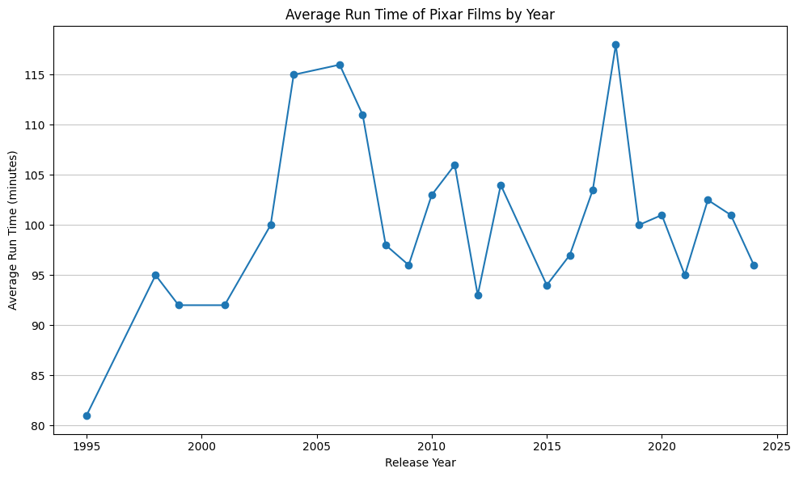

```python
# Calculate the average run time per year
avg_run_time_per_year = pixar_films.groupby('release_year')['run_time'].mean()

# Plot the average run time per year
plt.figure(figsize=(10, 6))
plt.plot(avg_run_time_per_year.index, avg_run_time_per_year.values, marker='o')
plt.title('Average Run Time of Pixar Films by Year')
plt.xlabel('Release Year')
plt.ylabel('Average Run Time (minutes)')
plt.grid(axis='y', linestyle='-', alpha=0.7)
plt.tight_layout()
plt.savefig(os.path.join(fig_dir, 'Average Run Time of Pixar Films by Year.jpg'), format='jpg', dpi=300)
plt.show()
```

The first Pixar Movie was the shortes. After 1995 the duration of films vary from 90 to 115 minutes. Despite one pick moment, from year 2007 until now the runtime became more stable - 95-100 minutes.

Genre and Subgenre distribution.

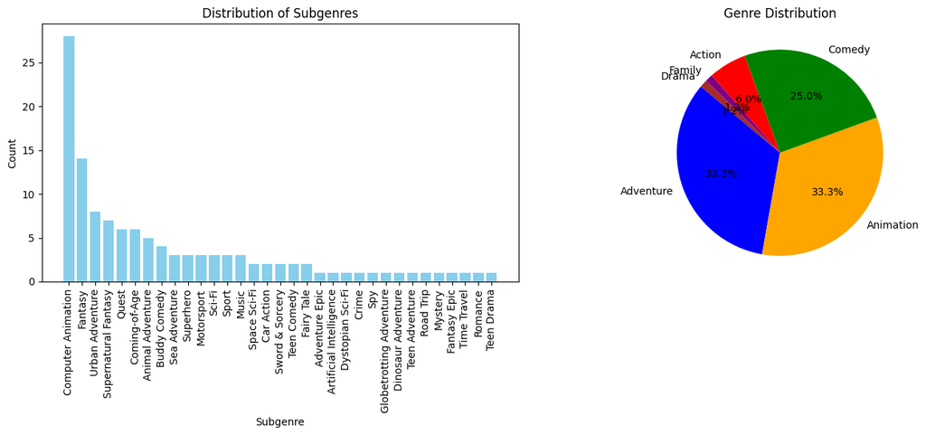

```python
# Create a figure with 2 subplots
fig, axes = plt.subplots(1, 2, figsize=(14, 6))

# First subplot: Distribution of subgenres
subgenre_counts = genres[genres['category'] == 'Subgenre']['value'].value_counts()
axes[0].bar(subgenre_counts.index, subgenre_counts.values, color='skyblue')
axes[0].set_title('Distribution of Subgenres')
axes[0].set_xlabel('Subgenre')
axes[0].set_ylabel('Count')
axes[0].tick_params(axis='x', rotation=90)

# Second subplot: Pie chart of genres
genre_counts = genres[genres['category'] == 'Genre']['value'].value_counts()
axes[1].pie(genre_counts.values, labels=genre_counts.index, autopct='%1.1f%%', startangle=140, colors=['blue', 'orange', 'green', 'red', 'purple', 'brown'])
axes[1].set_title('Genre Distribution')

# Adjust layout
plt.tight_layout()
plt.savefig(os.path.join(fig_dir, 'Genre and Subgenre Distribution.jpg'), format='jpg', dpi=300)
plt.show()
```

Left bar chart describe the distribution of Subgenres. As we see, all the films have a subgenre 'Computer Animation', which is pretty clear. The second most popular subgenre is 'Fantasy'. The least popular one is 'Teen Drama'.

Right pie chart is a proportion of the main genres. Of course, 'Animation' is the biggest sector. Then goes 'Adventure'. Here 'Family' and 'Drama' are outsiders.

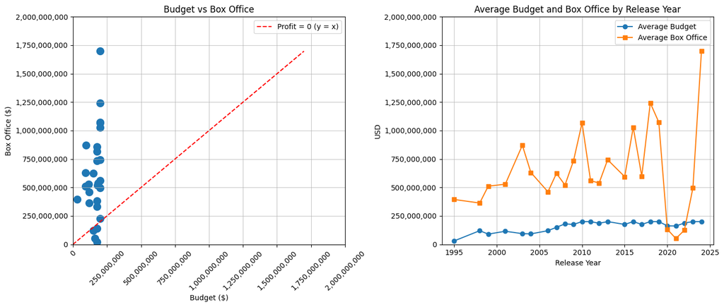

```python
# Merge data
merged_films_box_office = pd.merge(pixar_films, box_office, on='film')
avg_by_year = merged_films_box_office.groupby('release_year')[['budget', 'box_office_worldwide']].mean()

# Formatter for large numbers
formatter = tick.FuncFormatter(lambda x, _: f'{int(x):,}')

# Create subplots
fig, axs = plt.subplots(1, 2, figsize=(14, 6))

# Subplot 1: Scatter with y = x line
axs[0].scatter(box_office['budget'], box_office['box_office_worldwide'], s=100)
max_val = max(box_office['budget'].max(), box_office['box_office_worldwide'].max())
axs[0].plot([0, max_val], [0, max_val], 'r--', label='Profit = 0 (y = x)')
axs[0].set_ylim(0, 2_000_000_000)
axs[0].yaxis.set_major_formatter(formatter)
axs[0].set_xlim(0, 2_000_000_000)
axs[0].xaxis.set_major_formatter(formatter)
axs[0].tick_params(axis='x', rotation=45)
axs[0].set_title('Budget vs Box Office')
axs[0].set_xlabel('Budget ($)')
axs[0].set_ylabel('Box Office ($)')
axs[0].legend()
axs[0].grid(True, linestyle='-', alpha=0.7)

# Subplot 2: Average by release year
axs[1].plot(avg_by_year.index, avg_by_year['budget'], marker='o', label='Average Budget')
axs[1].plot(avg_by_year.index, avg_by_year['box_office_worldwide'], marker='s', label='Average Box Office')
axs[1].set_ylim(0, 2_000_000_000)
axs[1].yaxis.set_major_formatter(formatter)
axs[1].set_title('Average Budget and Box Office by Release Year')
axs[1].set_xlabel('Release Year')
axs[1].set_ylabel('USD')
axs[1].legend()
axs[1].grid(True, linestyle='-', alpha=0.7)

plt.tight_layout()
plt.savefig(os.path.join(fig_dir, 'Budget vs Box Office for each film and by Year.jpg'), format='jpg', dpi=300)
plt.show()
```

Left plot: there are dots which represent films. The red line is responsible for zero profit. So, we see that there are 4 movies having their profit negative. The majority of points are above the red dashed line.

```python
# Calculate profit
box_office['profit'] = box_office['box_office_worldwide'] - box_office['budget']

box_office.sort_values(by='profit', ascending=False, inplace=True)

# Print out the profit of all films
box_office[['film', 'profit']]
```

|  | film | profit |
| --- | --- | --- |
| 27 | Inside Out 2 | 1.498031e+09 |
| 19 | Incredibles 2 | 1.042805e+09 |
| 20 | Toy Story 4 | 8.733946e+08 |
| 10 | Toy Story 3 | 8.669697e+08 |
| 16 | Finding Dory | 8.285709e+08 |
| 4 | Finding Nemo | 7.770150e+08 |
| 14 | Inside Out | 6.826112e+08 |
| 18 | Coco | 6.396412e+08 |
| 9 | Up | 5.600991e+08 |
| 13 | Monsters University | 5.435596e+08 |
| 5 | The Incredibles | 5.394421e+08 |
| 7 | Ratatouille | 4.737261e+08 |
| 2 | Toy Story 2 | 4.213583e+08 |
| 3 | Monsters, Inc. | 4.137732e+08 |
| 0 | Toy Story | 3.644366e+08 |
| 11 | Cars 2 | 3.598524e+08 |
| 12 | Brave | 3.539832e+08 |
| 6 | Cars | 3.419831e+08 |
| 8 | WALL-E | 3.413119e+08 |
| 26 | Elemental | 2.964443e+08 |
| 1 | A Bug's Life | 2.432589e+08 |
| 17 | Cars 3 | 2.089307e+08 |
| 15 | The Good Dinosaur | 1.572077e+08 |
| 25 | Lightyear | 2.642542e+07 |
| 22 | Soul | -2.809612e+07 |
| 21 | Onward | -3.305996e+07 |
| 23 | Luca | -1.100358e+08 |
| 24 | Turning Red | -1.531866e+08 |

What are films with the highest profit?

```python
# Top 3 films by the highest profit
top_3_films = box_office.nlargest(3, 'profit')
top_3_films
```

|  | film | budget | box_office_worldwide | profit |
| --- | --- | --- | --- | --- |
| 27 | Inside Out 2 | 200000000.0 | 1698030965 | 1.498031e+09 |
| 19 | Incredibles 2 | 200000000.0 | 1242805359 | 1.042805e+09 |
| 20 | Toy Story 4 | 200000000.0 | 1073394593 | 8.733946e+08 |

What are films with the worst profit?

```python
# Top 3 worst films by profit but not with negative profit
# (i.e., films that made money but not as much as others)

# Filter out films with negative profit
positive_profit_films = box_office[box_office['profit'] > 0]

positive_profit_films.count()

# Get the top 3 worst films by profit
positive_profit_films = positive_profit_films.nsmallest(3, 'profit')
positive_profit_films
```

|  | film | budget | box_office_worldwide | profit |
| --- | --- | --- | --- | --- |
| 25 | Lightyear | 200000000.0 | 226425420 | 26425420.0 |
| 15 | The Good Dinosaur | 175000000.0 | 332207671 | 157207671.0 |
| 17 | Cars 3 | 175000000.0 | 383930656 | 208930656.0 |

Let's print all the films with negative profit (according to previous plots, there must be 4 of them).

```python
# films that made a loss
loss_films = box_office[box_office['profit'] < 0]
print("Films with loss:")
(loss_films[['film', 'budget', 'box_office_worldwide', 'profit']])
```

```
Films with loss:
```

|  | film | budget | box_office_worldwide | profit |
| --- | --- | --- | --- | --- |
| 22 | Soul | 1.500000e+08 | 121903885 | -2.809612e+07 |
| 21 | Onward | 1.750000e+08 | 141940042 | -3.305996e+07 |
| 23 | Luca | 1.611481e+08 | 51112314 | -1.100358e+08 |
| 24 | Turning Red | 1.750000e+08 | 21813358 | -1.531866e+08 |

Distribution plot for IMDb scores with a smooth KDE (kernel density estimate) line layered on top.

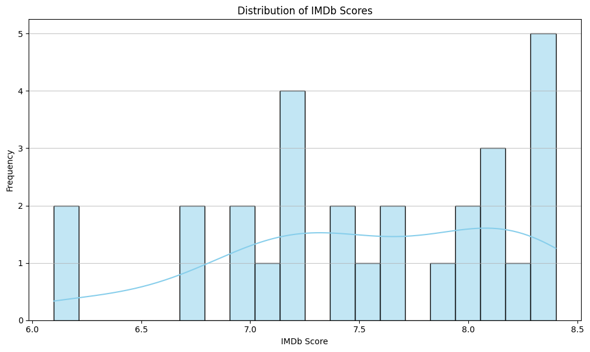

```python
# Create a distribution plot for IMDb scores
plt.figure(figsize=(10, 6))
sns.histplot(reviews['imdb_score'], bins=20, kde=True, color='skyblue')
plt.title('Distribution of IMDb Scores')
plt.xlabel('IMDb Score')
plt.ylabel('Frequency')
plt.grid(axis='y', linestyle='-', alpha=0.7)
plt.tight_layout()
plt.savefig(os.path.join(fig_dir, 'Distribution of IMDb Score.jpg'), format='jpg', dpi=300)
plt.show()
```

Most scores fall between 7.0 and 8.5, indicating strong general audience reception. The most frequent scores cluster around 8.4, the top of the spectrum.

The KDE curve is relatively flat and smooth, reflecting even spread across a good rating range.

Let's display average IMDb score by Genre.

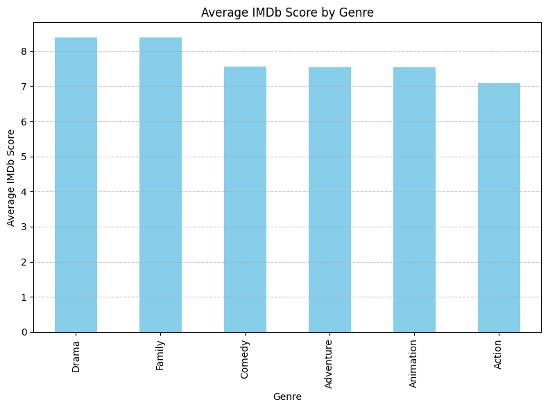

```python
# Filter genres only
genres_only = genres[genres['category'] == 'Genre']

# Merge on film
merged = pd.merge(genres_only, reviews, on='film')

# Group by genre and calculate mean IMDB score
genre_avg_score = merged.groupby('value')['imdb_score'].mean().sort_values(ascending=False)

# Plot
plt.figure(figsize=(8, 6))
genre_avg_score.plot(kind='bar', color='skyblue')
plt.title('Average IMDb Score by Genre')
plt.xlabel('Genre')
plt.ylabel('Average IMDb Score')
plt.grid(axis='y', linestyle='--', alpha=0.7)
plt.tight_layout()
plt.savefig(os.path.join(fig_dir, 'Average IMDb Score by Genre.jpg'), format='jpg', dpi=300)
plt.show()
```

As we see, genres 'Drama' and 'Family' have the highest score, however both are the rarest genres.

Still, all the genres have high enough scores.

What are the best films accourding to IMDb scores?

```python
# Top 3 films by IMDb score
top_3_imdb = reviews.nlargest(3, 'imdb_score')

top_3_imdb
```

|  | film | imdb_score | imdb_counts |
| --- | --- | --- | --- |
| 8 | WALL-E | 8.4 | 1226415 |
| 18 | Coco | 8.4 | 618005 |
| 0 | Toy Story | 8.3 | 1089101 |

What are the worst films accourding to IMDb scores?

```python
# Top 3 worst films by IMDb score
worst_3_imdb = reviews.nsmallest(3, 'imdb_score')
worst_3_imdb
```

|  | film | imdb_score | imdb_counts |
| --- | --- | --- | --- |
| 25 | Lightyear | 6.1 | 127045 |
| 11 | Cars 2 | 6.2 | 225724 |
| 15 | The Good Dinosaur | 6.7 | 130324 |

Let's demonstrate IMDb score vs Profit colored by Budget.

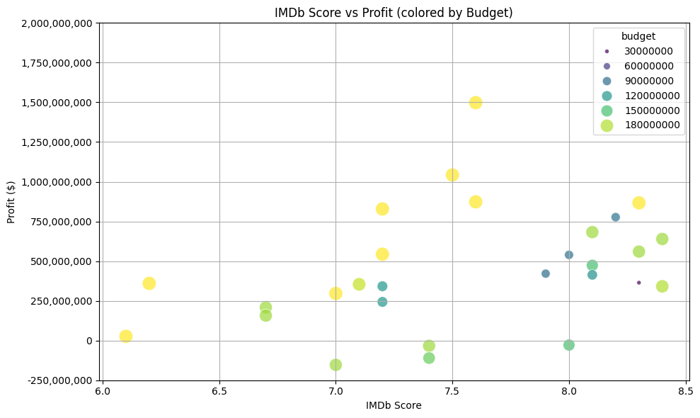

```python
# Merge datasets on 'film'
merged_box_office_reviews = pd.merge(box_office, reviews, on='film')

# Calculate profit
merged_box_office_reviews['profit'] = merged_box_office_reviews['box_office_worldwide'] - merged_box_office_reviews['budget']

# Plot: IMDb Score vs Profit in $, colored by budget
plt.figure(figsize=(10, 6))
sns.scatterplot(
    data=merged_box_office_reviews,
    x='imdb_score', y='profit',
    hue='budget', palette='viridis',
    size='budget', sizes=(20, 200), alpha=0.7
)

# Set axis limit and formatter
plt.ylim(-250_000_000, 2_000_000_000)
plt.gca().yaxis.set_major_formatter(formatter)

plt.title('IMDb Score vs Profit (colored by Budget)')
plt.xlabel('IMDb Score')
plt.ylabel('Profit ($)')
plt.grid()
plt.tight_layout()
plt.savefig(os.path.join(fig_dir, 'IMDb Score vs Profit (colored by Budget).jpg'), format='jpg', dpi=300)
plt.show()
```

Larger budget films (yellow/green dots) appear across the whole score range, indicating that a big budget doesn't guarantee high ratings.

A few films with mid-range scores (around 7.0–7.5) resulted in losses, even with significant budgets—showing critical reception isn’t always enough.

What are films with the highest IMDb scores and profits?

```python
# Top 5 films with the highest IMDb scores and profits
top_5_imdb_profit = merged_box_office_reviews.nlargest(5, 'profit')[['film', 'imdb_score', 'profit']]
top_5_imdb_profit
```

|  | film | imdb_score | profit |
| --- | --- | --- | --- |
| 0 | Inside Out 2 | 7.6 | 1.498031e+09 |
| 1 | Incredibles 2 | 7.5 | 1.042805e+09 |
| 2 | Toy Story 4 | 7.6 | 8.733946e+08 |
| 3 | Toy Story 3 | 8.3 | 8.669697e+08 |
| 4 | Finding Dory | 7.2 | 8.285709e+08 |

The most informative grafic is a correlation matrix. Let's see how different factors impact each other.

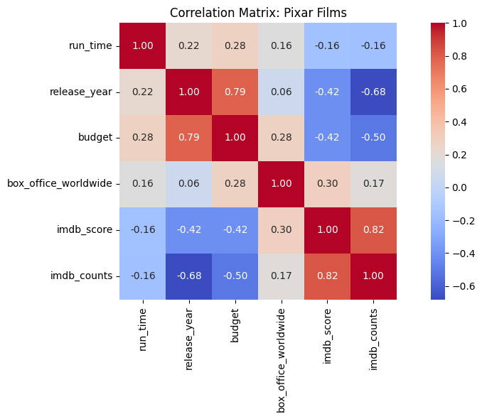

```python
# Merge all tables
merged = pd.merge(pixar_films, box_office, on='film')
merged = pd.merge(merged, reviews, on='film')

# Select columns of interest
corr_data = merged[['run_time', 'release_year', 'budget', 'box_office_worldwide', 'imdb_score', 'imdb_counts']]

# Compute correlation matrix
corr_matrix = corr_data.corr(numeric_only=True)

# Plot correlation heatmap
plt.figure(figsize=(10, 6))
sns.heatmap(corr_matrix, annot=True, cmap='coolwarm', fmt=".2f", square=True)
plt.title('Correlation Matrix: Pixar Films')
plt.tight_layout()
plt.savefig(os.path.join(fig_dir, 'Correlation Matrix.jpg'), format='jpg', dpi=300)
plt.show()
```

Strong Positive Correlations:

- budget vs release_year (0.79) -> Newer films tend to have higher budgets, likely due to inflation and industry trends.
- imdb_score vs imdb_counts (0.82) -> Higher-rated films tend to receive more votes, indicating greater popularity or wider reach.

Moderate Positive Correlations:

- budget vs box_office_worldwide (0.28) -> Higher budgets can help improve returns, but not a strong driver alone.
- imdb_score vs box_office_worldwide (0.30)

Notable Negative Correlations:

- release_year vs imdb_score (-0.42) -> Newer films may have slightly lower IMDb scores on average (or simply less time to accumulate ratings).
- release_year vs imdb_counts (-0.68) -> Recent films have fewer votes, likely due to shorter exposure.
- budget vs imdb_score (-0.42) -> Surprisingly, bigger budgets don’t correlate with better ratings.

# PREDICTION

We should prepare the data for machine learning and build predictive models for Pixar films' worldwide box office revenue:In the following cells, we prepare the data for machine learning and build predictive models for Pixar films' worldwide box office revenue.

We are not interested in subgenres, but genres theiselves.

Using one-hot encoding, we convert categorical variables (genre names) into a binary format.

Then, we need to merge several tables.

```python
# --- Preprocessing ---
# Delete all the subgenres from the genres dataset
genres_only= genres[~genres['category'].str.contains('Subgenre')]
genres_only=genres_only.drop(columns=['category'])
```

```python
# --- Preprocessing ---
genres_encoded = pd.get_dummies(genres_only, columns=['value'], prefix='', prefix_sep='')
genres_encoded = genres_encoded.groupby('film').sum().reset_index()
```

```python
# Merge datasets
merged = pd.merge(pixar_films, box_office, on='film')
merged = pd.merge(merged, reviews, on='film')
merged = pd.merge(merged, genres_encoded, on='film', how='left')

# Drop rows with missing values
merged = merged.dropna()
```

```python
# Feature matrix X and target y
feature_cols = ['budget', 'run_time', 'release_year'] + list(genres_encoded.columns[1:])
X = merged[feature_cols]
y = merged['box_office_worldwide']
```

To create a prediction we have to split data, train the model and predict. Also, we should evaluate the model. Here we are going to use Linear Regression Model (linear dependency) and Random Forest (non-linear dependency).

```python
# --- Modeling ---
X_train, X_test, y_train, y_test = train_test_split(X, y, test_size=0.2, random_state=42)

# Linear Regression
lr_model = LinearRegression()
lr_model.fit(X_train, y_train)
y_pred_lr = lr_model.predict(X_test)

# Random Forest Regressor
rf_model = RandomForestRegressor(random_state=42)
rf_model.fit(X_train, y_train)
y_pred_rf = rf_model.predict(X_test)

# --- Evaluation ---
def evaluate_model(name, y_true, y_pred):
    print(f"\n{name}:")
    print(f"R^2 Score: {r2_score(y_true, y_pred):.2f}")
    print(f"MAE: {mean_absolute_error(y_true, y_pred):,.0f}")
    print(f"RMSE: {np.sqrt(mean_squared_error(y_true, y_pred)) :,.0f}")

evaluate_model("Linear Regression", y_test, y_pred_lr)
evaluate_model("Random Forest", y_test, y_pred_rf)
```

```
Linear Regression:
R^2 Score: -3.09
MAE: 367,357,908
RMSE: 403,709,630

Random Forest:
R^2 Score: -0.41
MAE: 180,776,721
RMSE: 237,018,997
```

Linear Regression:

- R^2 Score: -3.09 -> Very poor.
- MAE: 367,357,908 -> On average, the model misses the target by $367 million.
- RMSE: 403,709,630 -> Prediction errors are typically very large and inconsistent.

Conclusion: The linear model fails to capture the relationships.

Random Forest:

- R^2 Score: -0.41 -> Still not good, but much better than linear regression.
- MAE: 180,776,721 -> On average, off by $181 million, about 50% better than the linear model.
- RMSE: 237,018,997 -> Errors are lower, showing more stability and robustness.

Conclusion: While Random Forest performs better, the negative R² indicates it's still not capturing patterns effectively.

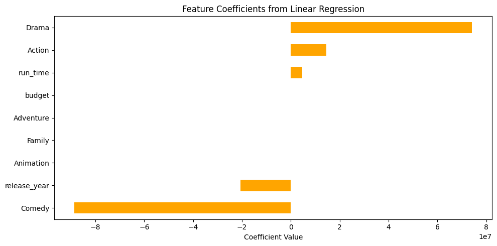

```python
# --- Feature Coefficients (Linear Regression) ---
lr_coefficients = pd.Series(lr_model.coef_, index=X.columns)
lr_coefficients_sorted = lr_coefficients.sort_values()

plt.figure(figsize=(10, 5))
lr_coefficients_sorted.plot(kind='barh', color='orange')
plt.xlabel("Coefficient Value")
plt.title("Feature Coefficients from Linear Regression")
plt.tight_layout()
plt.savefig(os.path.join(fig_dir, 'Feature Coefficients from Linear Regression.jpg'), format='jpg', dpi=300)
plt.show()
```

Feature coefficients from LR:

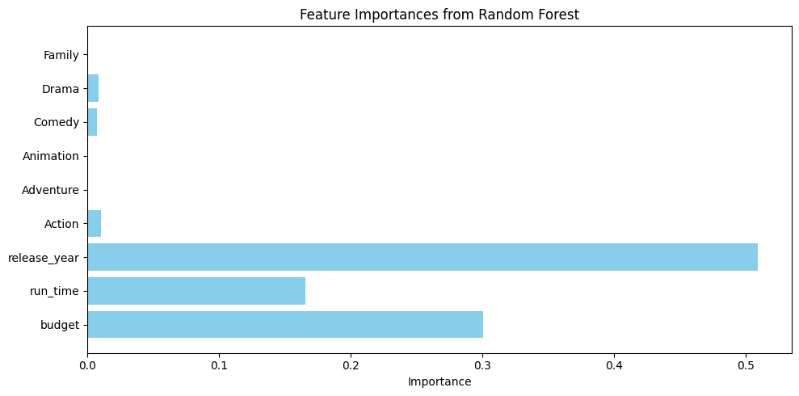

```python
# --- Feature Importance (Random Forest) ---
importances = rf_model.feature_importances_
feature_names = X.columns

plt.figure(figsize=(10, 5))
plt.barh(feature_names, importances, color='skyblue')
plt.xlabel("Importance")
plt.title("Feature Importances from Random Forest")
plt.tight_layout()
plt.savefig(os.path.join(fig_dir, 'Feature Importances from Random Forest.jpg'), format='jpg', dpi=300)
plt.show()
```

Feature coefficients from RF:

- Release Year: Indicates a strong temporal trend: newer films likely earn more due to inflation, distribution reach, or branding effects.
- Budget: As expected, films with higher budgets typically perform better at the box office.
- Run Time: Longer films may signal deeper narratives or bigger productions, contributing to profit.
- Genres (Comedy, Drama, Family): Extremely low importance in this model.

```python
# Predict a bow office of  anew  unseen film Elio

# Feature setup
X_columns = ['budget', 'run_time', 'release_year', 'Adventure', 'Animation', 'Comedy', 'Drama', 'Action', 'Family']
for col in X_columns:
    if col not in merged.columns:
        merged[col] = 0

X = merged[X_columns]
y = merged['box_office_worldwide']

# Train models
X_train, X_test, y_train, y_test = train_test_split(X, y, test_size=0.2, random_state=42)
lr_model = LinearRegression().fit(X_train, y_train)
rf_model = RandomForestRegressor(random_state=42).fit(X_train, y_train)

# New input for prediction
new_film = pd.DataFrame([{
    'budget': 300_000_000,
    'run_time': 99,
    'release_year': 2024,
    'Adventure': 1,
    'Animation': 1,
    'Comedy': 1,
    'Drama': 1,
    'Action': 0,
    'Family': 0
}], columns=X_columns)

# Predictions
predicted_box_office_lr = lr_model.predict(new_film)[0]
predicted_box_office_rf = rf_model.predict(new_film)[0]

print(predicted_box_office_lr, predicted_box_office_rf)
```

```
1411207516.7095413 1180528886.91
```

Linear Regression says that the box office will be $1.4 billion.

Randon Forest says that the box office will be $1.2 billion.

```python
# Stop saving
pp.close()
```